# CIA+Factbook+SQLite+Query+and+Analysis

**SQLite and CIA Factbook Analysis**

The goal of this project is to use basic SQL functionality (through SQLite) to pull basic data from the CIA World Factbook and use Python to analyze its contents. The prompt and goals of this project were provided by the DataQuest bootcamp (https://www.dataquest.io/).

**Introduction**

We begin by importing pandas and sqlite3 libraries and connecting to the SQLite database "factbook.db" hosted at a GitHub repo here: https://github.com/factbook/factbook.sql/releases

Then we create a cursor to traverse the data set and fetch results.

```python
import pandas as pd
import sqlite3

conn = sqlite3.connect("factbook.db")
cursor = conn.cursor()
```

Once that is done, we run queries 1 and 2 to test the database and our retrieval methods to make sure everything is working properly so far.

```python
q1 = "SELECT * FROM sqlite_master WHERE type='table';"
pd.read_sql_query(q1, conn)
```

|  | type | name | tbl_name | rootpage | sql |
| --- | --- | --- | --- | --- | --- |
| 0 | table | sqlite_sequence | sqlite_sequence | 3 | CREATE TABLE sqlite_sequence(name,seq) |
| 1 | table | facts | facts | 47 | CREATE TABLE "facts" ("id" INTEGER PRIMARY KEY... |

```python
cursor.execute(q1).fetchall()
```

```
[('table',
  'sqlite_sequence',
  'sqlite_sequence',
  3,
  'CREATE TABLE sqlite_sequence(name,seq)'),
 ('table',
  'facts',
  'facts',
  47,
  'CREATE TABLE "facts" ("id" INTEGER PRIMARY KEY AUTOINCREMENT NOT NULL, "code" varchar(255) NOT NULL, "name" varchar(255) NOT NULL, "area" integer, "area_land" integer, "area_water" integer, "population" integer, "population_growth" float, "birth_rate" float, "death_rate" float, "migration_rate" f…
```

```python
q2 = "SELECT * FROM facts LIMIT 5;"
pd.read_sql_query(q2, conn)
```

|  | id | code | name | area | area_land | area_water | population | population_growth | birth_rate | death_rate | migration_rate |
| --- | --- | --- | --- | --- | --- | --- | --- | --- | --- | --- | --- |
| 0 | 1 | af | Afghanistan | 652230 | 652230 | 0 | 32564342 | 2.32 | 38.57 | 13.89 | 1.51 |
| 1 | 2 | al | Albania | 28748 | 27398 | 1350 | 3029278 | 0.30 | 12.92 | 6.58 | 3.30 |
| 2 | 3 | ag | Algeria | 2381741 | 2381741 | 0 | 39542166 | 1.84 | 23.67 | 4.31 | 0.92 |
| 3 | 4 | an | Andorra | 468 | 468 | 0 | 85580 | 0.12 | 8.13 | 6.96 | 0.00 |
| 4 | 5 | ao | Angola | 1246700 | 1246700 | 0 | 19625353 | 2.78 | 38.78 | 11.49 | 0.46 |

**Basic Statistic Pulls**

Our next prompt for query 3 is to construct a single query that returns the maximum and minimum population figure contained in the factbook, as well as the minimum and maximum figure for population growth.

```python
q3 = "SELECT min(population) min_pop, max(population) max_pop, min(population_growth) min_pop_growth, max(population_growth) max_pop_growth from facts;"
pd.read_sql_query(q3, conn)
```

|  | min_pop | max_pop | min_pop_growth | max_pop_growth |
| --- | --- | --- | --- | --- |
| 0 | 0 | 7256490011 | 0.0 | 4.02 |

**Pull countries based on statistics**

We are then prompted to write a query (q4) to return the minimum population country, and then another query (q5) to return the maximum population nation.

```python
q4 = "SELECT * FROM facts WHERE population == (select min(population) from facts)"
pd.read_sql_query(q4, conn)
```

|  | id | code | name | area | area_land | area_water | population | population_growth | birth_rate | death_rate | migration_rate |
| --- | --- | --- | --- | --- | --- | --- | --- | --- | --- | --- | --- |
| 0 | 250 | ay | Antarctica | None | 280000 | None | 0 | None | None | None | None |

```python
q5 = "SELECT * FROM facts WHERE population == (select max(population) from facts);"

pd.read_sql_query(q5, conn)
```

|  | id | code | name | area | area_land | area_water | population | population_growth | birth_rate | death_rate | migration_rate |
| --- | --- | --- | --- | --- | --- | --- | --- | --- | --- | --- | --- |
| 0 | 261 | xx | World | None | None | None | 7256490011 | 1.08 | 18.6 | 7.8 | None |

*Results*

It looks like Antarctica unsurprisingly has the lowest population in the world.

The CIA factbook has decided to categorize the total world as its own entity with a separate row, so it would make sense that that row would have the highest population.

**Create plotted grids from SQL queries**

The next prompt instructs us to create a 2 by 2 grid of histograms from four columns: "population", "population_growth", "birth_rate", and "death_rate".

The first step is to import the necessary plotting libraries, create the right parameters for the histogram layout, and then build a single query (q6) to pull the data.

I will also remove the Antarctica and World rows from these queries as they are unhelpful outliers.

```
array([[<matplotlib.axes._subplots.AxesSubplot object at 0x7f1523312828>,
      dtype=object)
```

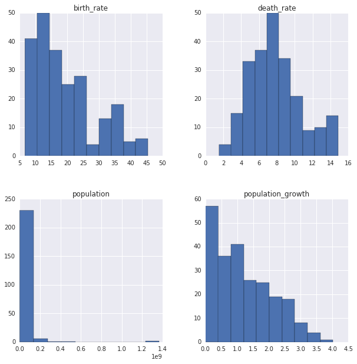

```python
import matplotlib.pyplot as plt
import seaborn as sns
%matplotlib inline

fig = plt.figure(figsize=(10,10))
ax = fig.add_subplot(111)

q6 = "SELECT population, population_growth, birth_rate, death_rate FROM facts where population != (select max(population) from facts) and population != (select min(population) from facts);"

pd.read_sql_query(q6, conn).hist(ax=ax)
```

*Results*

While death rate is unimodal, birth rate, population growth, and especially population skew to the right. Since histograms measure the relative frequency of ranges of data, this means different things for each histogram.

Birth rate: The x-axis measures the range of birth rates. As lower birth rates (i.e. birth rates under 25 births per 1,000 women per annum) are more frequent, this means that there are a small handful of very fertile countries while the majority skew to lower birth rates.

Death rate: Since this is a mostly even distribution, the death rate suggests a more homogeneous range of death rates across most nations centering between 6 to 10 deaths per 1,000 people per year. There is a slight uptick on the upper end of the tail, most likely for nations undergoing turmoil.

Population growth: The CIA Factbook measures population growth in terms of the percentage of the change in population each year In this case, the majority of countries have a population growth between 0 and 1.25% each year. The histogram seems to neglect negative values for population growth, this would have to be corrected in a subsequent analysis.

**Highest population density**

```python
q7 = "SELECT name, cast(population as float)/cast(area as float) density from facts order by density desc limit 20"
pd.read_sql_query(q7, conn)
```

|  | name | density |
| --- | --- | --- |
| 0 | Macau | 21168.964286 |
| 1 | Monaco | 15267.500000 |
| 2 | Singapore | 8141.279770 |
| 3 | Hong Kong | 6445.041516 |
| 4 | Gaza Strip | 5191.819444 |
| 5 | Gibraltar | 4876.333333 |
| 6 | Bahrain | 1771.859211 |
| 7 | Maldives | 1319.640940 |
| 8 | Malta | 1310.015823 |
| 9 | Bermuda | 1299.925926 |
| 10 | Sint Maarten | 1167.323529 |
| 11 | Bangladesh | 1138.069143 |
| 12 | Guernsey | 847.179487 |
| 13 | Jersey | 838.741379 |
| 14 | Barbados | 675.823256 |
| 15 | Mauritius | 656.777941 |
| 16 | Taiwan | 650.781712 |
| 17 | Aruba | 623.122222 |
| 18 | Lebanon | 594.682788 |
| 19 | Saint Martin | 588.037037 |

*Results*

As one could expect island city-nations rank the highest in population density with the exception of the Gaza Strip at #4 as a zoned off Palestinian political entity surrounded by the state of Israel.

The other oddity is St. Martin is listed at both #10 and #19 with its Dutch name being provided at #10. More research could uncover why the CIA factbook has duplicate entries for what seems to be the same geographical island nation.